# R Notebook

1. Load the data, clean_names() and explore it.

```r
library(prob)
library(janitor)
library(tidyverse)

mobile_data <- read_csv("data/20190928-items.csv") %>%
  clean_names()
```

```r
mobile_data %>%
  head()
```

| asin | brand | title | url | image | rating | review_url | total_reviews | prices |
| --- | --- | --- | --- | --- | --- | --- | --- | --- |
| B0000SX2UC | Nokia | Dual-Band / Tri-Mode Sprint PCS Phone w/ Voice Activated Dialing & Bright White Backlit Screen | https://www.amazon.com/Dual-Band-Tri-Mode-Activated-Dialing-Backlit/dp/B0000SX2UC | https://m.media-amazon.com/images/I/2143EBQ210L._AC_UY218_SEARCH213888_FMwebp_QL75_.jpg | 3.0 | https://www.amazon.com/product-reviews/B0000SX2UC | 14 | NA |
| B0009N5L7K | Motorola | Motorola I265 phone | https://www.amazon.com/Motorola-i265-I265-phone/dp/B0009N5L7K | https://m.media-amazon.com/images/I/419WBAVDARL._AC_UY218_SEARCH213888_FMwebp_QL75_.jpg | 2.9 | https://www.amazon.com/product-reviews/B0009N5L7K | 7 | $49.95 |
| B000SKTZ0S | Motorola | MOTOROLA C168i AT&T CINGULAR PREPAID GOPHONE CELL PHONE | https://www.amazon.com/MOTOROLA-C168i-CINGULAR-PREPAID-GOPHONE/dp/B000SKTZ0S | https://m.media-amazon.com/images/I/71b+q3ydkIS._AC_UY218_SEARCH213888_FMwebp_QL75_.jpg | 2.6 | https://www.amazon.com/product-reviews/B000SKTZ0S | 22 | NA |
| B00198M12M | Nokia | Nokia 6500 Slide Black/silver Unlocked Cell Phone | https://www.amazon.com/Nokia-6500-Slide-silver-Unlocked/dp/B00198M12M | https://m.media-amazon.com/images/I/41ss4HpLkLL._AC_UY218_SEARCH213888_FMwebp_QL75_.jpg | 2.4 | https://www.amazon.com/product-reviews/B00198M12M | 5 | NA |
| B001AO4OUC | Motorola | Motorola i335 Cell Phone Boost Mobile | https://www.amazon.com/Motorola-i335-Phone-Boost-Mobile/dp/B001AO4OUC | https://m.media-amazon.com/images/I/710UO8gdT+L._AC_UY218_SEARCH213888_FMwebp_QL75_.jpg | 3.3 | https://www.amazon.com/product-reviews/B001AO4OUC | 21 | NA |
| B001DCJAJG | Motorola | Motorola V365 no contract cellular phone AT&T | https://www.amazon.com/Motorola-V365-contract-cellular-phone/dp/B001DCJAJG | https://m.media-amazon.com/images/I/61LYNCVrrKL._AC_UY218_SEARCH213888_FMwebp_QL75_.jpg | 3.2 | https://www.amazon.com/product-reviews/B001DCJAJG | 12 | NA |

```r
mobile_data %>%
  sample_n(10) %>%
  select(-c(asin, url, image, review_url))
```

| brand | title | rating | total_reviews | prices |
| --- | --- | --- | --- | --- |
| Samsung | Samsung Galaxy Grand Prime - T-Mobile GSM Quad-Core Android Phone w/ 8MP Camera - Gray | 3.2 | 67 | NA |
| Apple | Apple iPhone 7, AT&T, 128GB - Red (Renewed) | 4.2 | 9 | $219.99 |
| Sony | Sony Xperia XA2 Ultra Factory Unlocked Phone - 6" Screen - 32GB - Blue (U.S. Warranty) | 3.8 | 281 | $399.99 |
| Samsung | Samsung Galaxy S4 M919 16GB Unlocked GSM 4G LTE Quad-Core Smartphone - White Frost | 2.6 | 30 | $169.93 |
| Motorola | Motorola Moto Z Play (XT1635) 32GB GSM Unlocked Android Smartphone, Black (Renewed) | 3.1 | 22 | $144.95 |
| Apple | Apple iPhone 5S 16GB GSM Unlocked, Space Gray (Renewed) | 3.4 | 4 | $80.00 |
| Samsung | Samsung Galaxy S7 Edge 32GB G935A GSM Unlocked (Renewed) (Black) | 3.5 | 248 | $184.83 |
| Samsung | Samsung Gusto, Black (Verizon Wireless) | 2.0 | 15 | NA |
| Motorola | Motorola V365 no contract cellular phone AT&T | 3.2 | 12 | NA |
| Samsung | Samsung Convoy SCH-U640 Cell Phone Ruggedized PTT 2+ megapixel Camera for Verizon | 3.4 | 102 | NA |

Q2. Find the brand with the highest numbers of phones in the dataset.

```r
#Checking that each phone is different
mobile_data %>%
  distinct(asin)
```

| asin |
| --- |
| B0000SX2UC |
| B0009N5L7K |
| B000SKTZ0S |
| B00198M12M |
| B001AO4OUC |
| B001DCJAJG |
| B001DZY4KI |
| B001GQ3DJM |
| B0027VKQPE |
| B00280QJFU |

[output cut: 782 more lines]

```r
mobile_data %>%
  group_by(brand) %>%
  summarise(count = n()) %>%
  slice_max(count)
```

| brand | count |
| --- | --- |
| Samsung | 397 |

Q3. For your top brand, plot the distribution of phone ratings as a probability density, overlaying a fitted normal distribution. Do you think the normal distribution provides a good model of these ratings?

Hint - you will need to calculate the mean() and sd() of the ratings to plot the appropriate normal.

```r
samsung_data <-
mobile_data %>%
  dplyr::filter(brand == "Samsung")


samsung_rating_stats <-
samsung_data %>%
  summarise(
    num = n(),
    mean = mean(rating),
    sd = sd(rating))

samsung_rating_stats
```

| num | mean | sd |
| --- | --- | --- |
| 397 | 3.5733 | 0.6847859 |

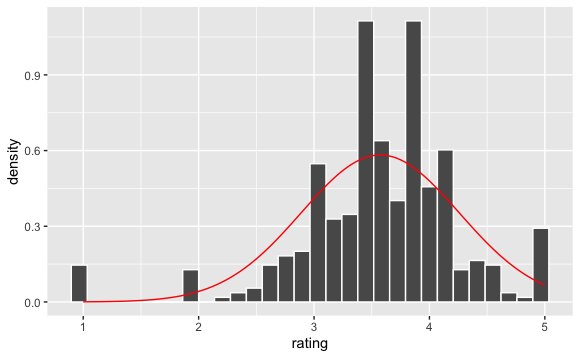

```r
samsung_data %>%
  ggplot(aes(x = rating)) +
  geom_histogram(aes(y = ..density..), col = "white", bins = 30) +
  stat_function(
    fun = dnorm,
    args = list(
      mean = samsung_rating_stats$mean,
      sd = samsung_rating_stats$sd
    ),
    col = "red"
  )
```

**I’m not quite sure to be honest. It looks like the general trend of the ratings follow a normal distribution quite well. However, it does look like there is maybe a bimodal distribution, with two peaks between 3 and 4. If I had to plunk for an answer though, I’d say yes, relatively normal distribution.**

Q4. We can be more quantitative in comparing the distribution of top brand ratings with a normal distribution. You calculated the mean() and sd() of your distribution in an earlier question. Use these values to calculate the proportions of ratings within one-, two- and three standard deviations of the mean. Compare these proportions with those you expect for a normal distribution.

```r
one_sd_samsung <-
samsung_data %>%
  dplyr::filter(
    rating >= samsung_rating_stats$mean - samsung_rating_stats$sd
    ) %>%
  dplyr::filter(
    rating <= samsung_rating_stats$mean + samsung_rating_stats$sd
    ) %>%
  summarise(prop_within_1sd = n() / nrow(samsung_rating_stats))

two_sd_samsung <-
samsung_data %>%
  dplyr::filter(
    rating >= samsung_rating_stats$mean - sum(2*samsung_rating_stats$sd)
    ) %>%
  dplyr::filter(
    rating <= samsung_rating_stats$mean + sum(2*samsung_rating_stats$sd)
    ) %>%
  summarise(prop_within_2sd = n() / nrow(samsung_rating_stats))

three_sd_samsung <-
samsung_data %>%
  dplyr::filter(
    rating >= samsung_rating_stats$mean - sum(3*samsung_rating_stats$sd)
    ) %>%
  dplyr::filter(
    rating <= samsung_rating_stats$mean + sum(3*samsung_rating_stats$sd)
    ) %>%
  summarise(prop_within_2sd = n() / nrow(samsung_rating_stats))
```

```r
sam_one_sd_prop =
one_sd_samsung$prop_within_1sd/samsung_rating_stats$num

sam_two_sd_prop =
two_sd_samsung$prop_within_2sd/samsung_rating_stats$num

sam_three_sd_prop =
three_sd_samsung$prop_within_2sd/samsung_rating_stats$num
```

```r
norm_one_sd_prop =
pnorm(q = 1) - pnorm(q = -1)

norm_two_sd_prop =
pnorm(q = 2) - pnorm(q = -2)

norm_three_sd_prop =
pnorm(q = 3) - pnorm(q = -3)
```

```r
norm_one_sd_prop - sam_one_sd_prop
```

```
[1] -0.1107614
```

**Looks like there is a just over 11% more observations within 1 standard deviation of the mean in the case of the samsung ratings when compared to normal distribution**

```r
norm_two_sd_prop - sam_two_sd_prop
```

```
[1] 0.03510427
```

**However, there is are over 3% less observations within two standard deviations of the mean in the case of the samsung ratings when compared to normal distribution**

```r
norm_three_sd_prop - sam_three_sd_prop
```

```
[1] 0.01745134
```

**Finally, it looks like are just under 2% less observations within 3 standard deviations of the mean in the case of the samsung ratings when compared to normal distribution.**

Extensions

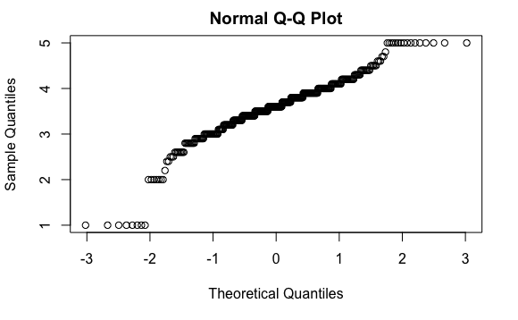

```r
qqnorm(samsung_data$rating)
```